# BADM590_FinalProject

Revati Shinde and other particpants of the group project

11/13/2022

First we must load the required libraries

```r
library(tidyverse)
library(rtweet)
```

```r
library(igraph)
library(psych)
```

Now we can load our data sets.

```r
#load tesla stock data
df_stock <- read_csv('TSLA (1).csv')
head(df_stock)
```

```
## # A tibble: 6 × 8
##   Date       Open  High   Low Close `Adj Close`   Volume   day
##   <chr>     <dbl> <dbl> <dbl> <dbl>       <dbl>    <dbl> <dbl>
## 1 7/6/2021   227.  228   217.  220.        220. 69853500     1
## 2 7/7/2021   221.  222.  213.  215.        215. 56376000     2
## 3 7/8/2021   209.  218.  207.  218.        218. 68319900     3
## 4 7/9/2021   218.  220.  215.  219.        219. 54421500     4
## 5 7/12/2021  221.  229.  221.  229.        229. 77781000     7
## 6 7/13/2021  229.  231.  222.  223.        223. 62898300     8
```

```r
#load elon's tweets
df_tweets <- read_csv('elonmusk.csv')
head(df_tweets)
```

```
## # A tibble: 6 × 4
##   date                  likes source             tweet
##   <dttm>                <dbl> <chr>              <chr>
## 1 2022-04-28 00:56:58 4812557 Twitter for iPhone Next I’m buying Coca-Cola to p…
## 2 2022-04-25 16:12:30 3259198 Twitter for iPhone I hope that even my worst crit…
## 3 2022-04-28 01:53:50 2673383 Twitter for iPhone Let’s make Twitter maximum fun!
## 4 2022-04-25 19:43:22 2629536 Twitter for iPhone 🚀💫♥️ Yesss!!! ♥️💫🚀 https://t…
## 5 2022-04-28 01:57:27 2600911 Twitter for iPhone Listen, I can’t do miracles ok…
## 6 2022-05-09 00:51:26 1902380 Twitter for iPhone If I die under mysterious circ…
```

```r
#load tesla sentiment data
df_sentiment <- read_csv('one-year-of-tsla-on-reddit-comments.csv')
```

```
## ──────────────────────────────────────────────────────── Delimiter: "," chr
## (6): type, id, subreddit.id, subreddit.name, permalink, body dbl (4):
## created_utc, sentiment, score, day lgl (2): subreddit.nsfw, ...12
```

```r
head(df_sentiment)
```

```
## # A tibble: 6 × 12
##   type   id    subre…¹ subre…² subre…³ creat…⁴ perma…⁵ body  senti…⁶ score   day
##   <chr>  <chr> <chr>   <chr>   <lgl>     <dbl> <chr>   <chr>   <dbl> <dbl> <dbl>
## 1 comme… h42t… 2tasy   person… FALSE    1.63e9 https:… "I t…  -0.202     3     1
## 2 comme… h42t… 2th52   wallst… FALSE    1.63e9 https:… "Guy…  -0.649    19     1
## 3 comme… h42u… 2rndg   valuei… FALSE    1.63e9 https:… "It …   0.554     4     1
## 4 comme… h42w… 2qjfk   stocks  FALSE    1.63e9 https:… "I i…   0.924    34     1
## 5 comme… h42x… 2th52   wallst… FALSE    1.63e9 https:… "$CL…  NA        -1     1
## 6 comme… h42x… 27n9fl  thetag… FALSE    1.63e9 https:… "Yea…   0.940     2     1
## # … with 1 more variable: ...12 <lgl>, and abbreviated variable names
## #   ¹subreddit.id, ²subreddit.name, ³subreddit.nsfw, ⁴created_utc, ⁵permalink,
## #   ⁶sentiment
```

Now that the data has all successfully loaded we may pre-process the data before beginning analysis. First we aggregate daily sentiment from df_sentiment.

```r
#aggregate daily sentiment for df_sentiment
agg_tbl <- df_sentiment %>% group_by(day) %>%
  summarise(mean_sentiment = mean(sentiment, na.rm = TRUE))
agg_tbl <- as.data.frame(agg_tbl)
agg_tbl
```

```
##     day mean_sentiment
## 1     1     0.28103741
## 2     2     0.11969318
## 3     3     0.20281203
## 4     4     0.16064167
## 5     5     0.15391398
## 6     6     0.21253026
## 7     7     0.27666299
## 8     8     0.13426395
## 9     9     0.13271084
## 10   10     0.10398892
## 11   11     0.14441146
## 12   12     0.20249377
## 13   13     0.29340377
## 14   14     0.34520847
```

[output cut: 351 more lines]

Next we join the aggregated sentiment (agg_tbl) with df_stock to have an associated sentiment with each day’s stock price.

```r
#combine mean_sentiment and df_stock
df_combined <- merge(df_stock, agg_tbl, by.x = 'day', by.y = 'day')
df_combined
```

```
##     day       Date     Open     High      Low    Close Adj Close    Volume
## 1     1   7/6/2021 227.2367 228.0000 217.1333 219.8600  219.8600  69853500
## 2     2   7/7/2021 221.4233 221.9000 212.7733 214.8833  214.8833  56376000
## 3     3   7/8/2021 209.4567 218.1433 206.8200 217.6033  217.6033  68319900
## 4     4   7/9/2021 217.7267 219.6367 214.8967 218.9833  218.9833  54421500
## 5     7  7/12/2021 220.7333 229.0800 220.7200 228.5667  228.5667  77781000
## 6     8  7/13/2021 228.7733 231.0933 222.1000 222.8467  222.8467  62898300
## 7     9  7/14/2021 223.5833 226.2033 217.6133 217.7933  217.7933  64923600
## 8    10  7/15/2021 219.4633 222.0467 212.6267 216.8667  216.8667  60628800
## 9    11  7/16/2021 218.2267 218.9000 214.0667 214.7400  214.7400  49113000
## 10   14  7/19/2021 209.9633 215.7333 207.0967 215.4067  215.4067  63891300
## 11   15  7/20/2021 217.3300 220.7967 213.5000 220.1667  220.1667  46461300
## 12   16  7/21/2021 219.8700 221.6200 216.7633 218.4300  218.4300  41859900
## 13   17  7/22/2021 218.8133 220.7233 214.8667 216.4200  216.4200  45317100
## 14   18  7/23/2021 215.4533 216.2667 212.4333 214.4600  214.4600  43814700
```

[output cut: 489 more lines]

Now we can pursue our first question: Does post sentiment have a statistically significant correlation with Tesla’s stock price? We’ll begin with a correlation plot to get an idea if there are any highly correlated variables.

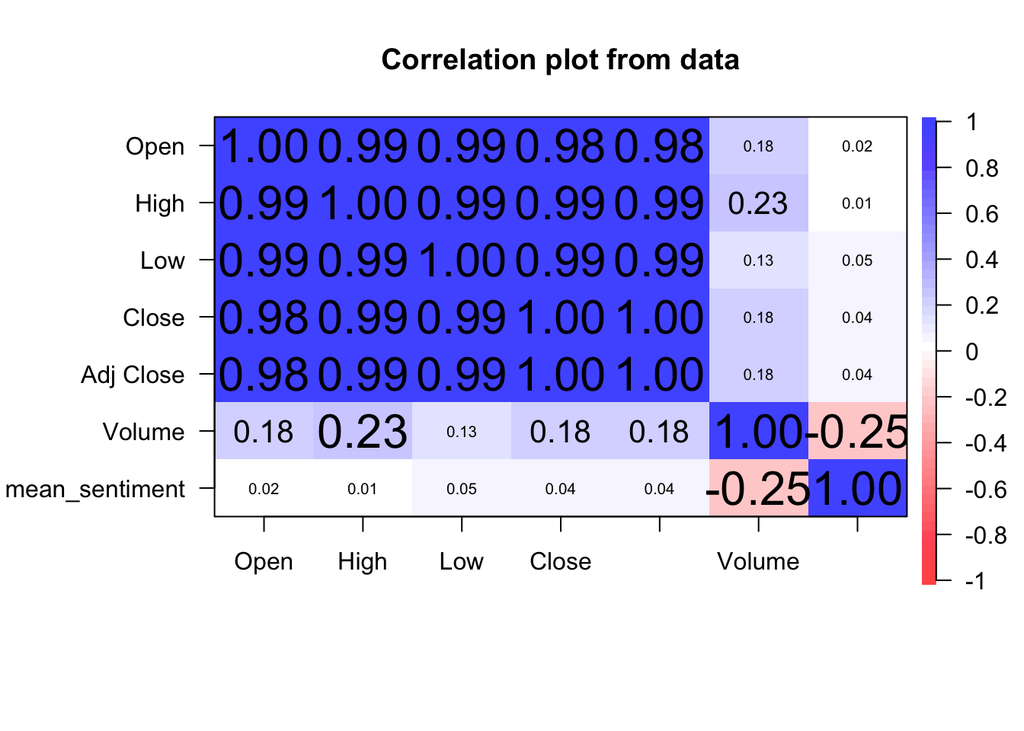

```r
df_test <- subset(df_combined, select = -c(day, Date))
corPlot(df_test)
```

We can see that the correlation between mean_sentiment and the stock prices tend to be low so this clues us in that there may not be a statistically significant relationship, however we’ll still need to run a regression to make sure. We can also note that interestingly, there is a slight correlation between mean_sentiment and Volume, so we may want to explore this variable as well.

```r
#correlation between Close and mean_sentiment
cor(df_combined$Close, df_combined$mean_sentiment)
```

```
## [1] 0.04268976
```

A simple correlation test says no, but we’ll perform a linear regression with Close as the outcome and mean_sentiment as the predictor to check for significance as well.

```r
#regression with outcome 'Close' and predictor 'mean_sentiment'
lm1 <- lm(Close ~ mean_sentiment, data = df_combined)
summary(lm1)
```

```
##
## Call:
## lm(formula = Close ~ mean_sentiment, data = df_combined)
##
## Residuals:
##    Min     1Q Median     3Q    Max
## -78.82 -48.94  -4.16  48.85 120.36
##
## Coefficients:
##                Estimate Std. Error t value Pr(>|t|)
## (Intercept)     283.317      9.066  31.251   <2e-16 ***
## mean_sentiment   31.611     46.883   0.674    0.501
## ---
## Signif. codes:  0 '***' 0.001 '**' 0.01 '*' 0.05 '.' 0.1 ' ' 1
##
## Residual standard error: 53.2 on 249 degrees of freedom
## Multiple R-squared:  0.001822,   Adjusted R-squared:  -0.002186
## F-statistic: 0.4546 on 1 and 249 DF,  p-value: 0.5008
```

Next, we’ll examine the relationship between mean_sentiment and Volume since our plot indicated that these variables may have a significant relationship. First, the exact correlation.

```r
cor(df_combined$Volume, df_combined$mean_sentiment)
```

```
## [1] -0.2501751
```

So, interestingly there is a negative correlation, meaning that when users have a higher opinion of TSLA they are less likely to trade the stock. Let’s check if the relationship is significant with another simple linear regression.

```r
lm2 <- lm(Volume ~ mean_sentiment, data = df_combined)
summary(lm2)
```

```
##
## Call:
## lm(formula = Volume ~ mean_sentiment, data = df_combined)
##
## Residuals:
##       Min        1Q    Median        3Q       Max
## -51935245 -17956769  -3434527  13046139 125786752
##
## Coefficients:
##                 Estimate Std. Error t value Pr(>|t|)
## (Intercept)     93328419    4467692  20.890  < 2e-16 ***
## mean_sentiment -94204684   23104370  -4.077 6.13e-05 ***
## ---
## Signif. codes:  0 '***' 0.001 '**' 0.01 '*' 0.05 '.' 0.1 ' ' 1
##
## Residual standard error: 26220000 on 249 degrees of freedom
## Multiple R-squared:  0.06259,    Adjusted R-squared:  0.05882
## F-statistic: 16.62 on 1 and 249 DF,  p-value: 6.133e-05
```

As we can see, not only is there no correlation between user sentiment and Tesla stock price, but the p-value of mean_sentiment is over 0.5, therefore any relationship between the variables would be insignificant regardless. We can then say that our first hypothesis is disproved, and user sentiment has no statistically significant correlation with Tesla stock price. However, our analysis of Volume shows otherwise given that the p-value in lm2 is less than 0.05. Therefore, even though user sentiment has no relationship with TSLA price, it indeed has a statistically significant impact on trading volume. Now we can move on to testing out second question: Do statements made by Elon Musk correlate with a change to Tesla stock price? We’ll also include Volume in this analysis since it was identified as a potentially useful variable in our previous analysis. We’ll begin by identifying Elon’s most liked tweet between the years 2021-2022.

```r
#sort df_tweets by Number of Likes
newdata <- df_tweets[order(df_tweets$likes, decreasing = TRUE), ]

#check the date for most liked tweet
head(newdata)
```

```
## # A tibble: 6 × 4
##   date                  likes source             tweet
##   <dttm>                <dbl> <chr>              <chr>
## 1 2022-04-28 00:56:58 4812557 Twitter for iPhone Next I’m buying Coca-Cola to p…
## 2 2022-04-25 16:12:30 3259198 Twitter for iPhone I hope that even my worst crit…
## 3 2022-04-28 01:53:50 2673383 Twitter for iPhone Let’s make Twitter maximum fun!
## 4 2022-04-25 19:43:22 2629536 Twitter for iPhone 🚀💫♥️ Yesss!!! ♥️💫🚀 https://t…
## 5 2022-04-28 01:57:27 2600911 Twitter for iPhone Listen, I can’t do miracles ok…
## 6 2022-05-09 00:51:26 1902380 Twitter for iPhone If I die under mysterious circ…
```

We can see that Elon’s most liked tweet is on April 28th of 2022, which is associated with day 297 in our df_combined data frame. Therefore, we’ll analyze the mean closing price (Close) and trading volume (Volume) for the 3 days before and after day 297 using a T-test to see if the tweet had a significant impact on TSLA price.

```r
#create dataset for three days before
df_before <- df_combined %>% filter(day < 297)
df_before <- df_before %>% filter(day > 291)
head(df_before)
```

```
##   day      Date     Open     High      Low    Close Adj Close    Volume
## 1 294 4/25/2022 326.3233 336.2067 325.1000 332.6733  332.6733  68341200
## 2 295 4/26/2022 331.8100 333.3333 291.6667 292.1400  292.1400 136133700
## 3 296 4/27/2022 299.5267 306.0000 292.4533 293.8367  293.8367  76956300
##   mean_sentiment
## 1     0.20163581
## 2     0.14692506
## 3     0.08941449
```

```r
#create dataset for three days after
df_after <- df_combined %>% filter(day > 297)
df_after <- df_after %>% filter(day < 303)
head(df_after)
```

```
##   day      Date     Open     High      Low    Close Adj Close   Volume
## 1 298 4/29/2022 300.7500 311.4667 290.0000 290.2533  290.2533 88133100
## 2 301  5/2/2022 286.9233 302.1200 282.6767 300.9800  300.9800 75781500
## 3 302  5/3/2022 301.0600 308.0267 296.1967 303.0833  303.0833 63709500
##   mean_sentiment
## 1      0.1062598
## 2      0.1867152
## 3      0.1381934
```

Now that we have three days of data before and after April 28th (day 297), we can conduct the two sample T-test to see if there is a statistically significant difference in mean Close and Volume.

```r
#t-test
x <- df_before$Close
y <- df_after$Close
t.test(x, y, alternative = 'two.sided', var.equal = FALSE)
```

```
##
##  Welch Two Sample t-test
##
## data:  x and y
## t = 0.58688, df = 2.3574, p-value = 0.6086
## alternative hypothesis: true difference in means is not equal to 0
## 95 percent confidence interval:
##  -43.49852  59.72075
## sample estimates:
## mean of x mean of y
##  306.2167  298.1056
```

```r
#t-test
x <- df_before$Volume
y <- df_after$Volume
t.test(x, y, alternative = 'two.sided', var.equal = FALSE)
```

```
##
##  Welch Two Sample t-test
##
## data:  x and y
## t = 0.79915, df = 2.4328, p-value = 0.4948
## alternative hypothesis: true difference in means is not equal to 0
## 95 percent confidence interval:
##  -63900193  99771593
## sample estimates:
## mean of x mean of y
##  93810400  75874700
```

We can see that the p-values are 0.61 and 0.49 respectively (greater than 0.05), therefore there is not a statistically significant difference in stock price or trading volume before and after Elon tweeted his most liked tweet. But, perhaps most likes is not a good metric to determine which tweet may have the most impact on swaying users’ behavior in the market. Therefore, we also want to analyze the difference in stock price before and after a specific tweet. For instance, on September 22nd, 2021 (day 79), Elon tweeted that Tesla is rolling out a test for a Tesla insurance policy in Texas based on analytics of the drivers’ behavior to calculate rates. This signifies both a new major analytics initiative for Tesla, and the business entering into a new market, insurance. Therefore, we would expect that this news would have an impact on traders’ perception of TSLA future performance.

```r
#create dataset for three days before
df_before2 <- df_combined %>% filter(day < 79)
df_before2 <- df_before2 %>% filter(day > 73)
head(df_before2)
```

```
##   day      Date     Open     High    Low    Close Adj Close   Volume
## 1  74 9/17/2021 252.3833 253.6800 250.00 253.1633  253.1633 84612600
## 2  77 9/20/2021 244.8533 247.3333 239.54 243.3900  243.3900 74273100
## 3  78 9/21/2021 244.9300 248.2467 243.48 246.4600  246.4600 48992100
##   mean_sentiment
## 1      0.1789379
## 2      0.2927655
## 3      0.1533901
```

```r
#create dataset for three days after
df_after2 <- df_combined %>% filter(day > 79)
df_after2 <- df_after2 %>% filter(day < 85)
head(df_after2)
```

```
##   day      Date     Open     High      Low    Close Adj Close   Volume
## 1  80 9/23/2021 251.6667 252.7333 249.3067 251.2133  251.2133 35842500
## 2  81 9/24/2021 248.6300 258.2667 248.1867 258.1300  258.1300 64119000
## 3  84 9/27/2021 257.7067 266.3333 256.4367 263.7867  263.7867 84212100
##   mean_sentiment
## 1      0.2461038
## 2      0.2555126
## 3      0.2329523
```

Now that we have three days of data before and after September 22nd (day 79), we can conduct the two sample T-test to see if there is a statistically significant difference in mean Close and Volume.

```r
#t-test
x2 <- df_before2$Close
y2 <- df_after2$Close
t.test(x2, y2, alternative = 'two.sided', var.equal = FALSE)
```

```
##
##  Welch Two Sample t-test
##
## data:  x2 and y2
## t = -2.1628, df = 3.8039, p-value = 0.1001
## alternative hypothesis: true difference in means is not equal to 0
## 95 percent confidence interval:
##  -23.192402   3.114612
## sample estimates:
## mean of x mean of y
##  247.6711  257.7100
```

```r
#t-test
x2 <- df_before2$Volume
y2 <- df_after2$Volume
t.test(x2, y2, alternative = 'two.sided', var.equal = FALSE)
```

```
##
##  Welch Two Sample t-test
##
## data:  x2 and y2
## t = 0.44967, df = 3.7189, p-value = 0.6779
## alternative hypothesis: true difference in means is not equal to 0
## 95 percent confidence interval:
##  -42374905  58177705
## sample estimates:
## mean of x mean of y
##  69292600  61391200
```

We can see that the p-values are 0.10 and 0.68 respectively (greater than 0.05), therefore there is not a statistically significant difference in stock price or trading volume before and after Elon tweeted about the new analytics initiative and business venture. Therefore, both our initial hypotheses can be disproved through the analysis we’ve conducted. Despite the intuition led by the stereotype that Elon’s online behavior and user perception of him has a significant impact on TSLA’s performance, we can see that this is not the case. Elon’s online behavior and user sentiment of Tesla has no statistically significant impact on TSLA’s performance, with the only significant impact being found on trading volume rather than stock price.